# Flights Data Exploration

## by: Fahad Almani

## Preliminary Wrangling

> The dataset about flights in the United States in 2008, in dataset there are 7M records and 29 columns.

```python
# import all packages and set plots to be embedded inline
import numpy as np
import pandas as pd
import matplotlib.pyplot as plt
import seaborn as sb

%matplotlib inline
```

> Load in your dataset and describe its properties through the questions below. Try and motivate your exploration goals through this section.

```python
dataframe = pd.read_csv('2008.csv')
dataframe.shape[0]
```

```
7009728
```

```python
dataframe.info()
```

```
<class 'pandas.core.frame.DataFrame'>
RangeIndex: 7009728 entries, 0 to 7009727
Data columns (total 29 columns):
 #   Column             Dtype
---  ------             -----
 0   Year               int64
 1   Month              int64
 2   DayofMonth         int64
 3   DayOfWeek          int64
 4   DepTime            float64
 5   CRSDepTime         int64
 6   ArrTime            float64
 7   CRSArrTime         int64
 8   UniqueCarrier      object
 9   FlightNum          int64
```

[output cut: 21 more lines]

```python
columns = dataframe.columns
for col in columns:
    print(col, dataframe[col].isnull().sum())
```

```
Year 0
Month 0
DayofMonth 0
DayOfWeek 0
DepTime 136246
CRSDepTime 0
ArrTime 151649
CRSArrTime 0
UniqueCarrier 0
FlightNum 0
TailNum 83365
ActualElapsedTime 154699
CRSElapsedTime 844
AirTime 154699
ArrDelay 154699
DepDelay 136246
Origin 0
Dest 0
Distance 0
TaxiIn 151649
TaxiOut 137058
Cancelled 0
CancellationCode 6872294
Diverted 0
CarrierDelay 5484993
WeatherDelay 5484993
NASDelay 5484993
SecurityDelay 5484993
LateAircraftDelay 5484993
```

```python
dataframe.drop(['DepTime', 'CRSDepTime', 'ArrTime', 'CRSArrTime', 'TailNum',
                'CarrierDelay', 'Origin', 'Dest','TaxiIn', 'TaxiOut', 'WeatherDelay',
                'NASDelay', 'SecurityDelay', 'LateAircraftDelay', 'Diverted'],axis=1, inplace=True)
```

```python
dataframe.head(20)
```

|  | Year | Month | DayofMonth | DayOfWeek | UniqueCarrier | FlightNum | ActualElapsedTime | CRSElapsedTime | AirTime | ArrDelay | DepDelay | Distance | Cancelled | CancellationCode |
| --- | --- | --- | --- | --- | --- | --- | --- | --- | --- | --- | --- | --- | --- | --- |
| 0 | 2008 | 1 | 3 | 4 | WN | 335 | 128.0 | 150.0 | 116.0 | -14.0 | 8.0 | 810 | 0 | NaN |
| 1 | 2008 | 1 | 3 | 4 | WN | 3231 | 128.0 | 145.0 | 113.0 | 2.0 | 19.0 | 810 | 0 | NaN |
| 2 | 2008 | 1 | 3 | 4 | WN | 448 | 96.0 | 90.0 | 76.0 | 14.0 | 8.0 | 515 | 0 | NaN |
| 3 | 2008 | 1 | 3 | 4 | WN | 1746 | 88.0 | 90.0 | 78.0 | -6.0 | -4.0 | 515 | 0 | NaN |
| 4 | 2008 | 1 | 3 | 4 | WN | 3920 | 90.0 | 90.0 | 77.0 | 34.0 | 34.0 | 515 | 0 | NaN |
| 5 | 2008 | 1 | 3 | 4 | WN | 378 | 101.0 | 115.0 | 87.0 | 11.0 | 25.0 | 688 | 0 | NaN |
| 6 | 2008 | 1 | 3 | 4 | WN | 509 | 240.0 | 250.0 | 230.0 | 57.0 | 67.0 | 1591 | 0 | NaN |
| 7 | 2008 | 1 | 3 | 4 | WN | 535 | 233.0 | 250.0 | 219.0 | -18.0 | -1.0 | 1591 | 0 | NaN |
| 8 | 2008 | 1 | 3 | 4 | WN | 11 | 95.0 | 95.0 | 70.0 | 2.0 | 2.0 | 451 | 0 | NaN |
| 9 | 2008 | 1 | 3 | 4 | WN | 810 | 79.0 | 95.0 | 70.0 | -16.0 | 0.0 | 451 | 0 | NaN |
| 10 | 2008 | 1 | 3 | 4 | WN | 100 | 130.0 | 135.0 | 106.0 | 1.0 | 6.0 | 828 | 0 | NaN |
| 11 | 2008 | 1 | 3 | 4 | WN | 1333 | 121.0 | 135.0 | 107.0 | 80.0 | 94.0 | 828 | 0 | NaN |
| 12 | 2008 | 1 | 3 | 4 | WN | 829 | 60.0 | 55.0 | 39.0 | 1.0 | -4.0 | 162 | 0 | NaN |
| 13 | 2008 | 1 | 3 | 4 | WN | 1016 | 65.0 | 55.0 | 37.0 | 10.0 | 0.0 | 162 | 0 | NaN |
| 14 | 2008 | 1 | 3 | 4 | WN | 1827 | 49.0 | 55.0 | 35.0 | -4.0 | 2.0 | 162 | 0 | NaN |
| 15 | 2008 | 1 | 3 | 4 | WN | 2272 | 52.0 | 50.0 | 37.0 | 11.0 | 9.0 | 162 | 0 | NaN |
| 16 | 2008 | 1 | 3 | 4 | WN | 675 | 228.0 | 240.0 | 213.0 | 15.0 | 27.0 | 1489 | 0 | NaN |
| 17 | 2008 | 1 | 3 | 4 | WN | 1144 | 226.0 | 250.0 | 205.0 | -15.0 | 9.0 | 1489 | 0 | NaN |
| 18 | 2008 | 1 | 3 | 4 | WN | 4 | 123.0 | 135.0 | 110.0 | 16.0 | 28.0 | 838 | 0 | NaN |
| 19 | 2008 | 1 | 3 | 4 | WN | 54 | 56.0 | 70.0 | 49.0 | 37.0 | 51.0 | 220 | 0 | NaN |

```python
index = dataframe.query('Cancelled == 1').index
dataframe.drop(index, axis=0, inplace=True)
dataframe.drop(['Cancelled', 'CancellationCode'], axis=1, inplace=True)
dataframe.reset_index(inplace=True)
```

```python
dataframe.dropna(axis=0, inplace=True)
```

```python
columns = dataframe.columns
for col in columns:
    print(col, dataframe[col].isnull().sum())
```

```
index 0
Year 0
Month 0
DayofMonth 0
DayOfWeek 0
UniqueCarrier 0
FlightNum 0
ActualElapsedTime 0
CRSElapsedTime 0
AirTime 0
ArrDelay 0
DepDelay 0
Distance 0
```

```python
dataframe.Year = dataframe.Year.astype(str)
dataframe.Month = dataframe.Month.astype(str)
dataframe.DayofMonth = dataframe.DayofMonth.astype(str)

date = dataframe.DayofMonth + '-' + dataframe.Month + '-' + dataframe.Year
dataframe.insert(0,'date',date)
dataframe.date = pd.to_datetime(date)
dataframe.drop(['Year', 'Month', 'DayofMonth'], axis=1, inplace=True)
```

```python
dataframe.DayOfWeek.astype(str)

dataframe.loc[dataframe.DayOfWeek == 1, 'DayOfWeek'] = 'Monday'
dataframe.loc[dataframe.DayOfWeek == 2, 'DayOfWeek'] = 'Tuesday'
dataframe.loc[dataframe.DayOfWeek == 3, 'DayOfWeek'] = 'Wednesday'
dataframe.loc[dataframe.DayOfWeek == 4, 'DayOfWeek'] = 'Thursday'
dataframe.loc[dataframe.DayOfWeek == 5, 'DayOfWeek'] = 'Friday'
dataframe.loc[dataframe.DayOfWeek == 6, 'DayOfWeek'] = 'Saturday'
dataframe.loc[dataframe.DayOfWeek == 7, 'DayOfWeek'] = 'Sunday'

dataframe.DayOfWeek
```

```
0          Thursday
1          Thursday
2          Thursday
3          Thursday
4          Thursday
             ...
6872289    Saturday
6872290    Saturday
6872291    Saturday
6872292    Saturday
6872293    Saturday
Name: DayOfWeek, Length: 6855029, dtype: object
```

```python
dataframe.head()
```

|  | date | index | DayOfWeek | UniqueCarrier | FlightNum | ActualElapsedTime | CRSElapsedTime | AirTime | ArrDelay | DepDelay | Distance |
| --- | --- | --- | --- | --- | --- | --- | --- | --- | --- | --- | --- |
| 0 | 2008-03-01 | 0 | Thursday | WN | 335 | 128.0 | 150.0 | 116.0 | -14.0 | 8.0 | 810 |
| 1 | 2008-03-01 | 1 | Thursday | WN | 3231 | 128.0 | 145.0 | 113.0 | 2.0 | 19.0 | 810 |
| 2 | 2008-03-01 | 2 | Thursday | WN | 448 | 96.0 | 90.0 | 76.0 | 14.0 | 8.0 | 515 |
| 3 | 2008-03-01 | 3 | Thursday | WN | 1746 | 88.0 | 90.0 | 78.0 | -6.0 | -4.0 | 515 |
| 4 | 2008-03-01 | 4 | Thursday | WN | 3920 | 90.0 | 90.0 | 77.0 | 34.0 | 34.0 | 515 |

```python
dataframe.info()
```

```
<class 'pandas.core.frame.DataFrame'>
Int64Index: 6855029 entries, 0 to 6872293
Data columns (total 11 columns):
 #   Column             Dtype
---  ------             -----
 0   date               datetime64[ns]
 1   index              int64
 2   DayOfWeek          object
 3   UniqueCarrier      object
 4   FlightNum          int64
 5   ActualElapsedTime  float64
 6   CRSElapsedTime     float64
 7   AirTime            float64
 8   ArrDelay           float64
 9   DepDelay           float64
 10  Distance           int64
dtypes: datetime64[ns](1), float64(5), int64(3), object(2)
memory usage: 627.6+ MB
```

```python
dataframe.shape
```

```
(6855029, 11)
```

### What is the structure of your dataset?

> There are 6.85M flight in the dataset with 10 columns (date, DayOfWeek, UniqueCarrier, FlightNum, ActualElapsedTime, CRSElapsedTime, AirTime, ArrDelay, DepDelay, Distance). There are 7 columns numeric and 3 columns categorical.

### What is/are the main feature(s) of interest in your dataset?

> The most feature interest at dataset (ActualElapsedTime, CRSElapsedTime) to predict delay.

### What features in the dataset do you think will help support your investigation into your feature(s) of interest?

> The strongest columns effect on each flight is (DayOfWeek, Distance, AirTime, UniqueCarrier,) this column will support me to predict the flight delay.

## Univariate Exploration

> In this section, investigate distributions of individual variables. If you see unusual points or outliers, take a deeper look to clean things up and prepare yourself to look at relationships between variables.

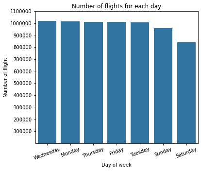

```python
Bin = np.arange(100000, 1100000 + 100000,100000)
order =dataframe.DayOfWeek.value_counts().index
plt.figure(figsize=(6,5))
sb.countplot(data=dataframe, x='DayOfWeek',color= sb.color_palette()[0],order=order);
plt.title('Number of flights for each day')
plt.xlabel('Day of week')
plt.ylabel('Number of flight')
plt.xticks(rotation=20)
plt.yticks(Bin,Bin);
```

> Approximately all days have the same number of flights except (Sunday, Saturday)

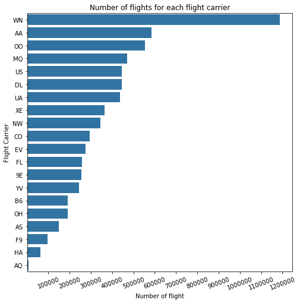

```python
Bin = np.arange(100000, 1200000 + 100000,100000)
order =dataframe.UniqueCarrier.value_counts().index
plt.figure(figsize=(8,8))
sb.countplot(data=dataframe, y='UniqueCarrier',color= sb.color_palette()[0],order=order);
plt.title('Number of flights for each flight carrier')
plt.ylabel('Flight Carrier')
plt.xlabel('Number of flight')
plt.xticks(Bin,Bin,rotation=20);
```

```python
print(dataframe.query('ArrDelay > 300').date.count(),dataframe.query('ArrDelay < -60').date.count())
dataframe.drop(dataframe.query('ArrDelay > 300').index, axis=0, inplace=True)
dataframe.drop(dataframe.query('ArrDelay < -60').index, axis=0, inplace=True)
```

```
10701 343
```

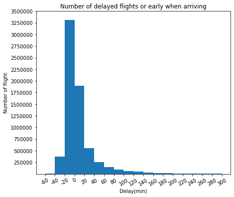

```python
xBin = np.arange(-60, 300 + 20, 20)
yBin = np.arange(250000, 3500000 + 250000, 250000)
plt.figure(figsize=(7,6))
plt.hist(dataframe.ArrDelay, bins=xBin)
plt.title('Number of delayed flights or early when arriving')
plt.xlabel('Delay(min)')
plt.ylabel('Number of flight')
plt.xticks(rotation=30)
plt.xticks(xBin,xBin)
plt.yticks(yBin,yBin);
```

> Most arrival flights arrive on time or before, and the data are right-skewed

```python
print(dataframe.query('DepDelay > 300').date.count(),dataframe.query('DepDelay < -60').date.count())
dataframe.drop(dataframe.query('DepDelay > 300').index, axis=0, inplace=True)
dataframe.drop(dataframe.query('DepDelay < -60').index, axis=0, inplace=True)
dataframe.reset_index(inplace=True)
```

```
789 18
```

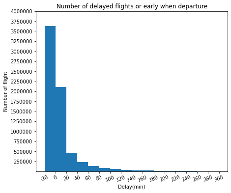

```python
xBin = np.arange(-20, 300 + 20, 20)
yBin = np.arange(250000, 4000000 + 250000, 250000)
plt.figure(figsize=(7,6))
plt.hist(dataframe.DepDelay, bins=xBin)
plt.title('Number of delayed flights or early when departure')
plt.xlabel('Delay(min)')
plt.ylabel('Number of flight')
plt.xticks(rotation=20)
plt.xticks(xBin,xBin)
plt.yticks(yBin,yBin);
```

> Most departures flights departures between 20 min before and 20 min after the schedule, and the data are right-skewed

### Discuss the distribution(s) of your variable(s) of interest. Were there any unusual points? Did you need to perform any transformations?

> Distribute data to columns (ArrDelay, DepDelay) right-skewed

### Of the features you investigated, were there any unusual distributions? Did you perform any operations on the data to tidy, adjust, or change the form of the data? If so, why did you do this?

> Remove outliers from (ArrDelay, DepDelay) columns.

## Bivariate Exploration

> In this section, investigate relationships between pairs of variables in your data. Make sure the variables that you cover here have been introduced in some fashion in the previous section (univariate exploration).

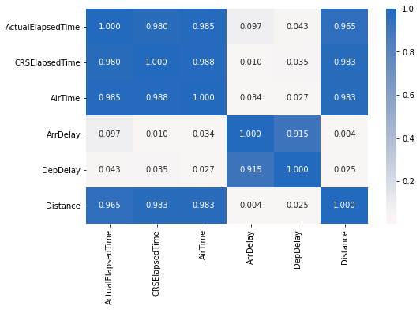

```python
numeric_vars = ['ActualElapsedTime', 'CRSElapsedTime', 'AirTime', 'ArrDelay',
       'DepDelay', 'Distance']
plt.figure(figsize = [8, 5])
sb.heatmap(dataframe[numeric_vars].corr(), annot = True, fmt = '.3f',cmap = 'vlag_r', center = 0);
```

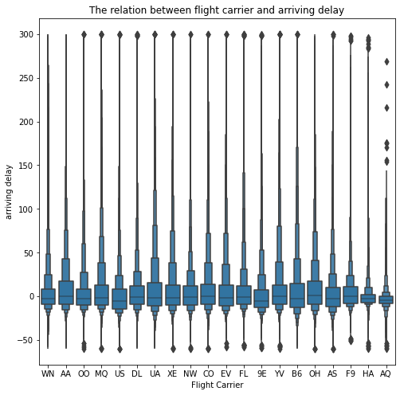

```python
plt.figure(figsize=(8,8))
order = dataframe.UniqueCarrier.value_counts().index
sb.boxenplot(data=dataframe, x='UniqueCarrier', y='ArrDelay', order=order, color=sb.color_palette()[0])
plt.title('The relation between flight carrier and arriving delay')
plt.xlabel('Flight Carrier')
plt.ylabel('arriving delay');
```

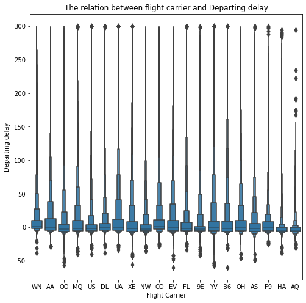

```python
plt.figure(figsize=(8,8))
order = dataframe.UniqueCarrier.value_counts().index
sb.boxenplot(data=dataframe, x='UniqueCarrier', y='DepDelay', order=order, color=sb.color_palette()[0])
plt.title('The relation between flight carrier and Departing delay')
plt.xlabel('Flight Carrier')
plt.ylabel('Departing delay');
```

```python
sample = dataframe.sample(dataframe.shape[0]//3)
```

To reduce draw figure process

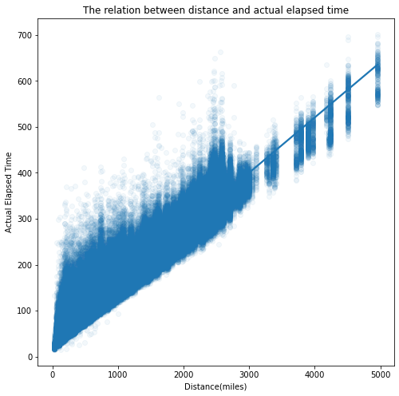

```python
plt.figure(figsize=(8,8))
sb.regplot(data=sample, x='Distance', y='ActualElapsedTime', x_jitter=0.3, scatter_kws={'alpha': 1/20})
plt.title('The relation between distance and actual elapsed time')
plt.xlabel('Distance(miles)')
plt.ylabel('Actual Elapsed Time');
```

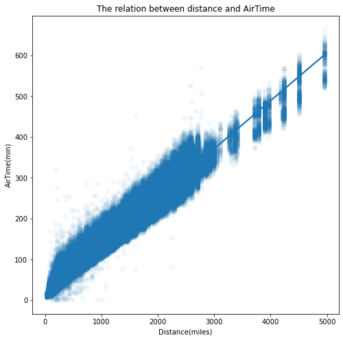

```python
plt.figure(figsize=(8,8))
sb.regplot(data=sample, x='Distance', y='AirTime', x_jitter=0.3, scatter_kws={'alpha': 1/20})
plt.title('The relation between distance and AirTime')
plt.xlabel('Distance(miles)')
plt.ylabel('AirTime(min)');
```

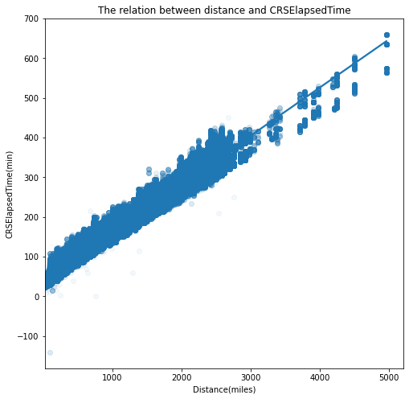

```python
plt.figure(figsize=(8,8))
sb.regplot(data=sample, x='Distance', y='CRSElapsedTime', x_jitter=0.3, scatter_kws={'alpha': 1/20})
plt.title('The relation between distance and CRSElapsedTime')
plt.xlabel('Distance(miles)')
plt.ylabel('CRSElapsedTime(min)');
```

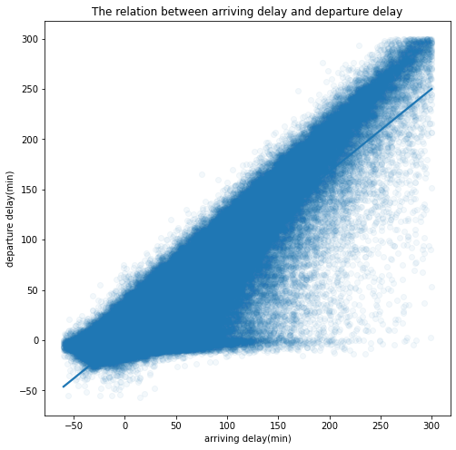

```python
plt.figure(figsize=(8,8))
sb.regplot(data=sample, x='ArrDelay', y='DepDelay', x_jitter=0.3, scatter_kws={'alpha': 1/20})
plt.title('The relation between arriving delay and departure delay')
plt.xlabel('arriving delay(min)')
plt.ylabel('departure delay(min)');
```

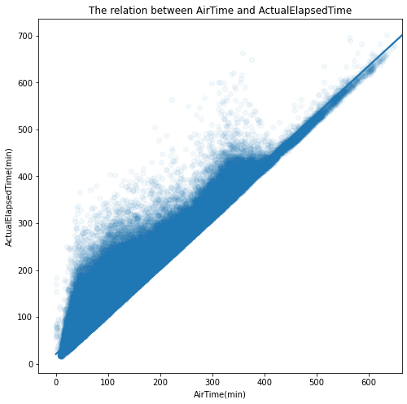

```python
plt.figure(figsize=(8,8))
sb.regplot(data=sample, x='AirTime', y='ActualElapsedTime', x_jitter=0.3, scatter_kws={'alpha': 1/20})
plt.title('The relation between AirTime and ActualElapsedTime')
plt.xlabel('AirTime(min)')
plt.ylabel('ActualElapsedTime(min)');
```

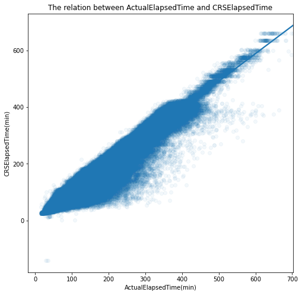

```python
plt.figure(figsize=(8,8))
sb.regplot(data=sample, x='ActualElapsedTime', y='CRSElapsedTime', x_jitter=0.3, scatter_kws={'alpha': 1/20})
plt.title('The relation between ActualElapsedTime and CRSElapsedTime')
plt.xlabel('ActualElapsedTime(min)')
plt.ylabel('CRSElapsedTime(min)');
```

[figure not shown]

```python
plt.figure(figsize=(8,8))
sb.regplot(data=sample, x='AirTime', y='CRSElapsedTime', x_jitter=0.3, scatter_kws={'alpha': 1/20})
plt.title('The relation between AirTime and CRSElapsedTime')
plt.xlabel('CRSElapsedTime(min)')
plt.ylabel('departure delay(min)');
```

### Talk about some of the relationships you observed in this part of the investigation. How did the feature(s) of interest vary with other features in the dataset?

> When ActualElapsedTime increase the CRSElapsedTime will increase it is a positive relationship that indicates the flight didn't take a long time to proper to the flight.

### Did you observe any interesting relationships between the other features (not the main feature(s) of interest)?

> The arriving delay and departure delay in the same flight will be similar or close to each, the distance column is very effective.

## Multivariate Exploration

> Create plots of three or more variables to investigate your data even further. Make sure that your investigations are justified, and follow from your work in the previous sections.

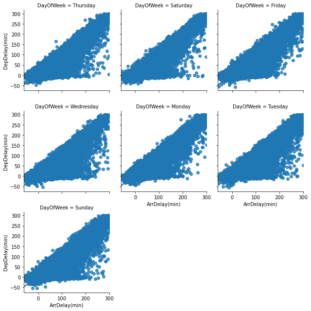

```python
Grid = sb.FacetGrid(data = sample, col = 'DayOfWeek', col_wrap = 3)
Grid.map(sb.regplot, 'ArrDelay', 'DepDelay')
Grid.set_xlabels('ArrDelay(min)')
Grid.set_ylabels('DepDelay(min)')
```

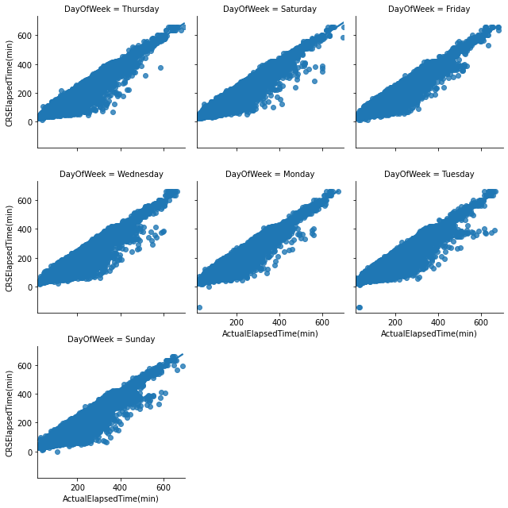

```python
Grid = sb.FacetGrid(data = sample, col = 'DayOfWeek', col_wrap = 3)
Grid.map(sb.regplot, 'ActualElapsedTime', 'CRSElapsedTime')
Grid.set_xlabels('ActualElapsedTime(min)')
Grid.set_ylabels('CRSElapsedTime(min)')
```

### Were there any interesting or surprising interactions between features?

> When a flight is delayed in arriving the departure delay will be the same or close from, that's because delay in arriving flight